# Week 10 - Homework

# Analysis #2: X-Rated Movies by Sex

The second analysis will be between men and women. The analysis will be differences in whether they watched an X-rated movie in the last year.

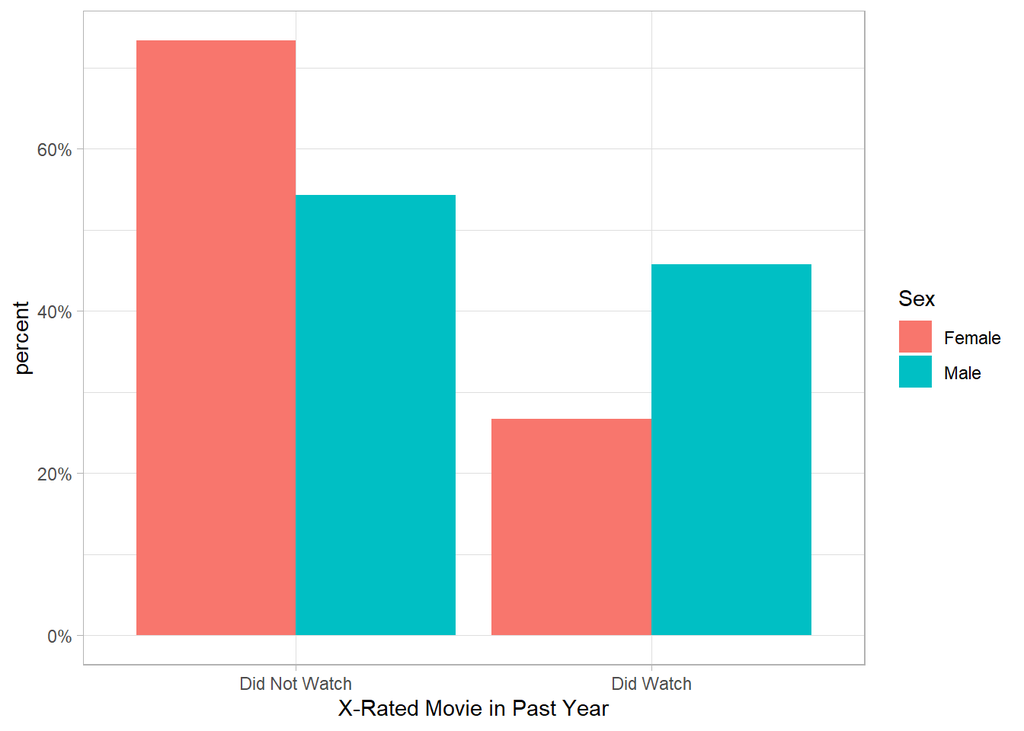

```r
sex_xrated <- gss2022 |>
  select(sex, xmovie) |> # select the sex variable and x-rated movie (comparison) variables
  drop_na() |>
  mutate(sex_label = if_else(sex == 1, "Male", "Female")) |>
  mutate(sex = if_else(sex == 1, 1, 0)) |>
  mutate(xmovie_label = if_else(xmovie==1, "Did Watch", "Did Not Watch")) |> # 1 is did watch, 2 is no
  mutate(xmovie = if_else(xmovie == 1, 1, 0)) # if xmovie is 0, they do not consume x-rated movie

sex_xrated_plot <- sex_xrated |>
  group_by(sex_label, xmovie_label) |> # group by sex and xrated movie watching
  summarize(n = n()) |> # get count with that combo
  mutate(percent = n/sum(n)) # get percent of group for each subgroup

ggplot(sex_xrated_plot,
       aes(x = xmovie_label,
           fill = sex_label,
           y = percent)) +
  geom_bar(position = "dodge",
           stat = "identity") +
  labs(x = "X-Rated Movie in Past Year",
       fill = "Sex") +
  scale_y_continuous(labels = scales::percent)
```

## Difference in Probability Regression

```r
mod1_sex_xrated <- glm(xmovie ~ sex,
            data = sex_xrated,
            family = binomial(link = "identity"))

summary(mod1_sex_xrated)
```

```
Call:
glm(formula = xmovie ~ sex, family = binomial(link = "identity"),
    data = sex_xrated)

Coefficients:
            Estimate Std. Error z value Pr(>|z|)
(Intercept)  0.26667    0.01599   16.68  < 2e-16 ***
sex          0.19076    0.02588    7.37 1.71e-13 ***
---
Signif. codes:  0 '***' 0.001 '**' 0.01 '*' 0.05 '.' 0.1 ' ' 1

(Dispersion parameter for binomial family taken to be 1)

    Null deviance: 1767.0  on 1363  degrees of freedom
Residual deviance: 1713.3  on 1362  degrees of freedom
AIC: 1717.3

Number of Fisher Scoring iterations: 2
```

The difference in probabilities regression suggests that men are 19.08 percentage points more likely to have watched an x-rated movie in the past year than women. The p-value for this estimate is less than our alpha level of .05, therefore we can reject the null hypothesis (no difference in probability).

## Risk Ratio Regression

```r
mod2_sex_xrated <- glm(xmovie ~ sex,
            data = sex_xrated,
            family = binomial(link = "log"))

summary(mod2_sex_xrated)
```

```
Call:
glm(formula = xmovie ~ sex, family = binomial(link = "log"),
    data = sex_xrated)

Coefficients:
            Estimate Std. Error z value Pr(>|z|)
(Intercept) -1.32176    0.05996 -22.045  < 2e-16 ***
sex          0.53962    0.07467   7.227 4.93e-13 ***
---
Signif. codes:  0 '***' 0.001 '**' 0.01 '*' 0.05 '.' 0.1 ' ' 1

(Dispersion parameter for binomial family taken to be 1)

    Null deviance: 1767.0  on 1363  degrees of freedom
Residual deviance: 1713.3  on 1362  degrees of freedom
AIC: 1717.3

Number of Fisher Scoring iterations: 6
```

```r
exp(summary(mod2_sex_xrated)$coefficients[2])
```

```
[1] 1.715359
```

The risk ratio regression suggests that men are 71.5358932 percent more likely to have watched an x-rated movie in the past year than women. The p-value for this estimate is less than our alpha level of .05, therefore we can reject the null hypothesis (no difference in risk).

## Logistic Regression

```r
mod3_sex_xrated <- glm(xmovie ~ sex,
            data = sex_xrated,
            family = binomial(link = "logit"))

summary(mod3_sex_xrated)
```

```
Call:
glm(formula = xmovie ~ sex, family = binomial(link = "logit"),
    data = sex_xrated)

Coefficients:
            Estimate Std. Error z value Pr(>|z|)
(Intercept) -1.01160    0.08176 -12.373  < 2e-16 ***
sex          0.84090    0.11581   7.261 3.83e-13 ***
---
Signif. codes:  0 '***' 0.001 '**' 0.01 '*' 0.05 '.' 0.1 ' ' 1

(Dispersion parameter for binomial family taken to be 1)

    Null deviance: 1767.0  on 1363  degrees of freedom
Residual deviance: 1713.3  on 1362  degrees of freedom
AIC: 1717.3

Number of Fisher Scoring iterations: 4
```

```r
exp(summary(mod3_sex_xrated)$coefficients[2])
```

```
[1] 2.318462
```

The logistic regression suggests that the odds of men having watched an x-rated movie in the past year are 2.3184615 times higher than for women. The p-value for this estimate is less than our alpha level of .05, therefore we can reject the null hypothesis (no difference in odds).

# Analysis #3: Happiness by Marital Status

The third analysis will be between married and unmarried respondents. The analysis will be differences in whether they reported being very happy.

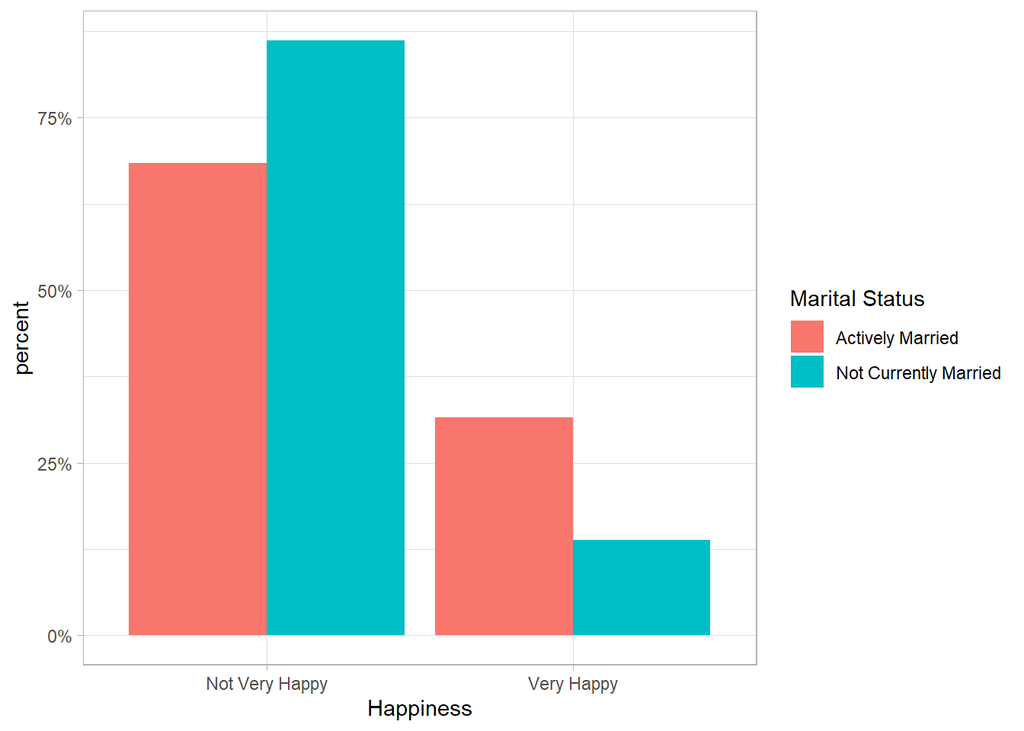

```r
marriage_happiness <- gss2022 |>
  select(marital, happy) |> # select the marriage variable and x-rated movie (comparison) variables
  drop_na() |>
  mutate(marriage_label = if_else(marital == 1, "Actively Married", "Not Currently Married")) |> #1 = married, 2+ is unmarried, widowed, etc.
  mutate(marriage = if_else(marital == 1, 1, 0)) |>
  mutate(happy_label = if_else(happy==1, "Very Happy", "Not Very Happy")) |> # 1 is very happy, 2 pretty happy, 3 not too happy
  mutate(happy = if_else(happy == 1, 1, 0)) # if happy is 1, very happy

marriage_happiness_plot <- marriage_happiness |>
  group_by(marriage_label, happy_label) |> # group by marriage and happiness
  summarize(n = n()) |> # get count with that combo
  mutate(percent = n/sum(n)) # get percent of group for each subgroup

ggplot(marriage_happiness_plot,
       aes(x = happy_label,
           fill = marriage_label,
           y = percent)) +
  geom_bar(position = "dodge",
           stat = "identity") +
  labs(x = "Happiness",
       fill = "Marital Status") +
  scale_y_continuous(labels = scales::percent)
```

## Difference in Probability Regression

```r
mod1_marriage_happiness <- glm(happy ~ marriage,
            data = marriage_happiness,
            family = binomial(link = "identity"))

summary(mod1_marriage_happiness)
```

```
Call:
glm(formula = happy ~ marriage, family = binomial(link = "identity"),
    data = marriage_happiness)

Coefficients:
            Estimate Std. Error z value Pr(>|z|)
(Intercept) 0.138655   0.007084   19.57   <2e-16 ***
marriage    0.177500   0.013243   13.40   <2e-16 ***
---
Signif. codes:  0 '***' 0.001 '**' 0.01 '*' 0.05 '.' 0.1 ' ' 1

(Dispersion parameter for binomial family taken to be 1)

    Null deviance: 4257.2  on 4106  degrees of freedom
Residual deviance: 4071.1  on 4105  degrees of freedom
AIC: 4075.1

Number of Fisher Scoring iterations: 2
```

The difference in probabilities regression suggests that married people are 17.75 percentage points more likely to be very happy than unmarried people. The p-value for this estimate is less than our alpha level of .05, therefore we can reject the null hypothesis (no difference in probability).

## Risk Ratio Regression

```r
mod2_marriage_happiness <- glm(happy ~ marriage,
            data = marriage_happiness,
            family = binomial(link = "log"))

summary(mod2_marriage_happiness)
```

```
Call:
glm(formula = happy ~ marriage, family = binomial(link = "log"),
    data = marriage_happiness)

Coefficients:
            Estimate Std. Error z value Pr(>|z|)
(Intercept) -1.97576    0.05109  -38.67   <2e-16 ***
marriage     0.82424    0.06215   13.26   <2e-16 ***
---
Signif. codes:  0 '***' 0.001 '**' 0.01 '*' 0.05 '.' 0.1 ' ' 1

(Dispersion parameter for binomial family taken to be 1)

    Null deviance: 4257.2  on 4106  degrees of freedom
Residual deviance: 4071.1  on 4105  degrees of freedom
AIC: 4075.1

Number of Fisher Scoring iterations: 6
```

```r
exp(summary(mod2_marriage_happiness)$coefficients[2])
```

```
[1] 2.280149
```

The risk ratio regression suggests that married people are 128.0149497 percent more likely to be very happy than unmarried people. The p-value for this estimate is less than our alpha level of .05, therefore we can reject the null hypothesis (no difference in risk).

## Logistic Regression

```r
mod3_marriage_happiness <- glm(happy ~ marriage,
            data = marriage_happiness,
            family = binomial(link = "logit"))

summary(mod3_marriage_happiness)
```

```
Call:
glm(formula = happy ~ marriage, family = binomial(link = "logit"),
    data = marriage_happiness)

Coefficients:
            Estimate Std. Error z value Pr(>|z|)
(Intercept) -1.82650    0.05931  -30.79   <2e-16 ***
marriage     1.05500    0.07872   13.40   <2e-16 ***
---
Signif. codes:  0 '***' 0.001 '**' 0.01 '*' 0.05 '.' 0.1 ' ' 1

(Dispersion parameter for binomial family taken to be 1)

    Null deviance: 4257.2  on 4106  degrees of freedom
Residual deviance: 4071.1  on 4105  degrees of freedom
AIC: 4075.1

Number of Fisher Scoring iterations: 4
```

```r
exp(summary(mod3_marriage_happiness)$coefficients[2])
```

```
[1] 2.871988
```

The logistic regression suggests that the odds of married people being very happy are 2.8719883 times higher than for unmarried people. The p-value for this estimate is less than our alpha level of .05, therefore we can reject the null hypothesis (no difference in odds).

# Analysis #4: Financial Satisfaction by Marital Status

The fourth analysis will be between married and unmarried respondents. The analysis will be differences in financial satisfaction.

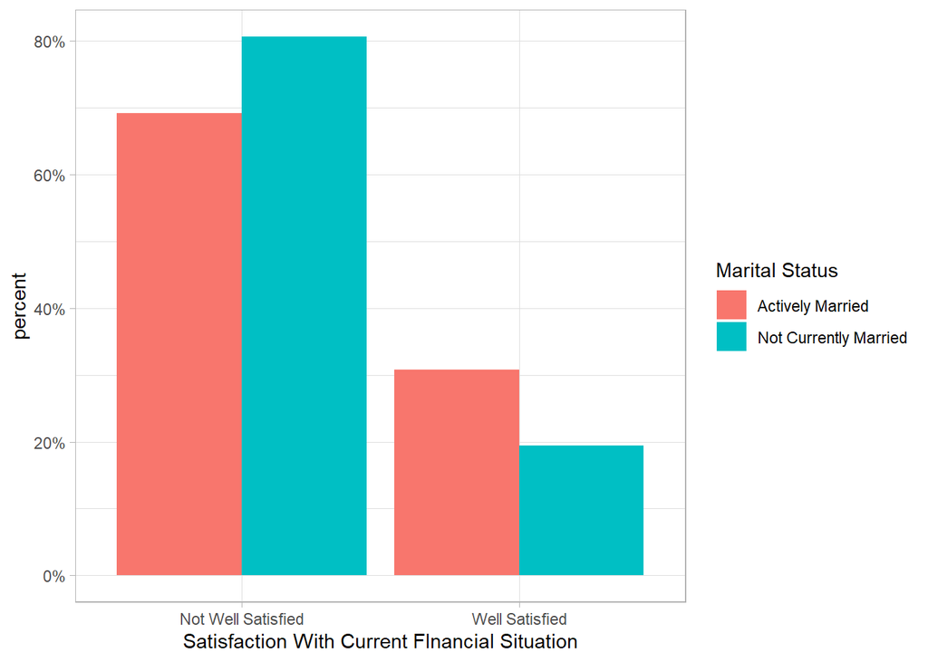

```r
marriage_finsatisfaction <- gss2022 |>
  select(marital, satfin) |> # select the marriage variable and x-rated movie (comparison) variables
  drop_na() |>
  mutate(marriage_label = if_else(marital == 1, "Actively Married", "Not Currently Married")) |> #1 = married, 2+ is unmarried, widowed, etc.
  mutate(marriage = if_else(marital == 1, 1, 0)) |>
  mutate(satfin_label = if_else(satfin==1, "Well Satisfied", "Not Well Satisfied")) |> # 1 is pretty well satisfied, 2+ is more/less and not satisfied
  mutate(satfin = if_else(satfin == 1, 1, 0)) # if satfin is 1, well satisfied

marriage_finsatisfaction_plot <- marriage_finsatisfaction |>
  group_by(marriage_label, satfin_label) |> # group by marriage and satisfaction
  summarize(n = n()) |> # get count with that combo
  mutate(percent = n/sum(n)) # get percent of group for each subgroup

ggplot(marriage_finsatisfaction_plot,
       aes(x = satfin_label,
           fill = marriage_label,
           y = percent)) +
  geom_bar(position = "dodge",
           stat = "identity") +
  labs(x = "Satisfaction With Current FInancial Situation",
       fill = "Marital Status") +
  scale_y_continuous(labels = scales::percent)
```

## Difference in Probability Regression

```r
mod1_marriage_finsatisfaction <- glm(satfin ~ marriage,
            data = marriage_finsatisfaction,
            family = binomial(link = "identity"))

summary(mod1_marriage_finsatisfaction)
```

```
Call:
glm(formula = satfin ~ marriage, family = binomial(link = "identity"),
    data = marriage_finsatisfaction)

Coefficients:
            Estimate Std. Error z value Pr(>|z|)
(Intercept) 0.193873   0.008098  23.940   <2e-16 ***
marriage    0.113997   0.013744   8.294   <2e-16 ***
---
Signif. codes:  0 '***' 0.001 '**' 0.01 '*' 0.05 '.' 0.1 ' ' 1

(Dispersion parameter for binomial family taken to be 1)

    Null deviance: 4547.9  on 4110  degrees of freedom
Residual deviance: 4477.6  on 4109  degrees of freedom
AIC: 4481.6

Number of Fisher Scoring iterations: 2
```

The difference in probabilities regression suggests that married people are 11.4 percentage points more likely to be satisfied with their financial situation than unmarried people. The p-value for this estimate is less than our alpha level of .05, therefore we can reject the null hypothesis (no difference in probability).

## Risk Ratio Regression

```r
mod2_marriage_finsatisfaction <- glm(satfin ~ marriage,
            data = marriage_finsatisfaction,
            family = binomial(link = "log"))

summary(mod2_marriage_finsatisfaction)
```

```
Call:
glm(formula = satfin ~ marriage, family = binomial(link = "log"),
    data = marriage_finsatisfaction)

Coefficients:
            Estimate Std. Error z value Pr(>|z|)
(Intercept) -1.64055    0.04177  -39.27   <2e-16 ***
marriage     0.46247    0.05519    8.38   <2e-16 ***
---
Signif. codes:  0 '***' 0.001 '**' 0.01 '*' 0.05 '.' 0.1 ' ' 1

(Dispersion parameter for binomial family taken to be 1)

    Null deviance: 4547.9  on 4110  degrees of freedom
Residual deviance: 4477.6  on 4109  degrees of freedom
AIC: 4481.6

Number of Fisher Scoring iterations: 6
```

```r
exp(summary(mod2_marriage_finsatisfaction)$coefficients[2])
```

```
[1] 1.587998
```

The risk ratio regression suggests that married people are 58.7998036 percent more likely to be satisfied with their financial situation than unmarried people. The p-value for this estimate is less than our alpha level of .05, therefore we can reject the null hypothesis (no difference in risk).

## Logistic Regression

```r
mod3_marriage_finsatisfaction <- glm(satfin ~ marriage,
            data = marriage_finsatisfaction,
            family = binomial(link = "logit"))

summary(mod3_marriage_finsatisfaction)
```

```
Call:
glm(formula = satfin ~ marriage, family = binomial(link = "logit"),
    data = marriage_finsatisfaction)

Coefficients:
            Estimate Std. Error z value Pr(>|z|)
(Intercept) -1.42504    0.05182 -27.501   <2e-16 ***
marriage     0.61494    0.07349   8.368   <2e-16 ***
---
Signif. codes:  0 '***' 0.001 '**' 0.01 '*' 0.05 '.' 0.1 ' ' 1

(Dispersion parameter for binomial family taken to be 1)

    Null deviance: 4547.9  on 4110  degrees of freedom
Residual deviance: 4477.6  on 4109  degrees of freedom
AIC: 4481.6

Number of Fisher Scoring iterations: 4
```

```r
exp(summary(mod3_marriage_finsatisfaction)$coefficients[2])
```

```
[1] 1.849549
```

The logistic regression suggests that the odds of married people being satisfied with their financial situation are 1.849549 times higher than for unmarried people. The p-value for this estimate is less than our alpha level of .05, therefore we can reject the null hypothesis (no difference in odds).